# Predictors of ctDNA positivity

```r
print(chisq_test)
```

```
    Pearson's Chi-squared test with Yates' continuity correction

data:  contingency_table
X-squared = 1.614, df = 1, p-value = 0.2039
```

```r
####inflammatory inflamm_yn -- IGNORE THIS for Table 1
table(d$inflamm_yn_1) ### i think the inflammatory folks must just not be in the subset of patients (6 yes's in the overall cohort, but none in the subset data for etierh inflamm variable)
```

```
  0   1
568  11
```

```r
table(d$inflamm_yn_2)  ### I think inflammatory folks just not in subset of patients in the dtc cohort
```

```
 0
24
```

```r
table(subset_data$inflamm_yn)
```

```
< table of extent 0 >
```

```r
#### radiation prtx_radiation
table(subset_data$prtx_radiation)
```

```
  0   1
116 282
```

```r
radiation <- subset_data |>
  distinct(participant_id,prtx_radiation) |>
  group_by(prtx_radiation) |>  # Group by stage
  summarise(count = n())  # Count the number of participants per histology type

# View the summary table
print(radiation)
```

```
# A tibble: 2 × 2
  prtx_radiation count
           <int> <int>
1              0    34
2              1    75
```

```r
# Summarize the data by participant_id
subset_data_by_id <- subset_data_clean |>
  group_by(participant_id) |>
  summarise(
    radiation = first(prtx_radiation),  # Get the final_overall_stage for each participant
    dtc_ever = first(dtc_ever)  # Get dtc_ever status for each participant
  )

# Create a contingency table of final_overall_stage vs dtc_ever
contingency_table <- table(subset_data_by_id$radiation, subset_data_by_id$dtc_ever)

# Perform the Chi-squared test
chisq_test <- chisq.test(contingency_table)
fishers <- fisher.test(contingency_table)
print(fishers)
```

```
    Fisher's Exact Test for Count Data

data:  contingency_table
p-value = 0.6709
alternative hypothesis: true odds ratio is not equal to 1
95 percent confidence interval:
 0.4916844 3.2745694
sample estimates:
odds ratio
  1.243166
```

```r
# Print the contingency table and Chi-squared test results --> p-val  = 0.77
print(contingency_table)
```

```
     0  1
  0 23 11
  1 47 28
```

```r
print(chisq_test)
```

```
    Pearson's Chi-squared test with Yates' continuity correction

data:  contingency_table
X-squared = 0.0823, df = 1, p-value = 0.7742
```

```r
#### chemotherapy prtx_chemo
table(subset_data$prtx_chemo)
```

```
  0   1
 18 380
```

```r
chemo <- subset_data |>
  distinct(participant_id,prtx_chemo) |>
  group_by(prtx_chemo) |>  # Group by stage
  summarise(count = n())  # Count the number of participants per histology type

# View the summary table
print(chemo) #3 people didn not get chemo in this cohort
```

```
# A tibble: 2 × 2
  prtx_chemo count
       <int> <int>
1          0     3
2          1   106
```

```r
# Summarize the data by participant_id
subset_data_by_id <- subset_data_clean |>
  group_by(participant_id) |>
  summarise(
    chemo = first(prtx_chemo),  # Get the final_overall_stage for each participant
    dtc_ever = first(dtc_ever)  # Get dtc_ever status for each participant
  )

# Create a contingency table of final_overall_stage vs dtc_ever
contingency_table <- table(subset_data_by_id$chemo, subset_data_by_id$dtc_ever)

# Perform the Chi-squared test
chisq_test <- chisq.test(contingency_table)
fishers <- fisher.test(contingency_table)
print(fishers)
```

```
    Fisher's Exact Test for Count Data

data:  contingency_table
p-value = 0.2906
alternative hypothesis: true odds ratio is not equal to 1
95 percent confidence interval:
 0.00448755 5.37725419
sample estimates:
odds ratio
 0.2715663
```

```r
# Print the contingency table and Chi-squared test results --> p-val  = 0.60
print(contingency_table)
```

```
     0  1
  0  1  2
  1 69 37
```

```r
print(chisq_test)
```

```
    Pearson's Chi-squared test with Yates' continuity correction

data:  contingency_table
X-squared = 0.27148, df = 1, p-value = 0.6023
```

```r
####neoadjuvant chemo diag_neoadj_chemo_1 or diag_neoadj_chemo_2

table(subset_data$diag_neoadj_chemo_1)
```

```
  0   1
327  71
```

```r
table(subset_data$diag_neoadj_chemo_2) #there were no ppl who were recorded on the second biopsy form as having neoadjuvant therapy so can use only the first variable
```

```
 0
20
```

```r
nact <- subset_data |>
  distinct(participant_id,diag_neoadj_chemo_1) |>
  group_by(diag_neoadj_chemo_1) |>  # Group by stage
  summarise(count = n())  # Count the number of participants per histology type

# View the summary table
print(nact) #3 people didn not get chemo in this cohort
```

```
# A tibble: 2 × 2
  diag_neoadj_chemo_1 count
                <int> <int>
1                   0    90
2                   1    19
```

```r
# Summarize the data by participant_id
subset_data_by_id <- subset_data_clean |>
  group_by(participant_id) |>
  summarise(
    nact = first(diag_neoadj_chemo_1),  # Get the final_overall_stage for each participant
    dtc_ever = first(dtc_ever)  # Get dtc_ever status for each participant
  )

# Create a contingency table of final_overall_stage vs dtc_ever
contingency_table <- table(subset_data_by_id$nact, subset_data_by_id$dtc_ever)

# Perform the Chi-squared test
chisq_test <- chisq.test(contingency_table)

# Print the contingency table and Chi-squared test results --> p-val  = 0.37 slightly greater trend than with ctDNA
print(contingency_table)
```

```
     0  1
  0 60 30
  1 10  9
```

```r
print(chisq_test)
```

```
    Pearson's Chi-squared test with Yates' continuity correction

data:  contingency_table
X-squared = 0.80344, df = 1, p-value = 0.3701
```

```r
####hormone therapy prtx_endo

table(subset_data$prtx_endo)
```

```
  0   1
156 242
```

```r
endo <- subset_data |>
  distinct(participant_id,prtx_endo) |>
  group_by(prtx_endo) |>  # Group by stage
  summarise(count = n())  # Count the number of participants per histology type

# View the summary table
print(endo) #most ppl did get endo (62 of the 109)
```

```
# A tibble: 2 × 2
  prtx_endo count
      <int> <int>
1         0    47
2         1    62
```

```r
# Summarize the data by participant_id
subset_data_by_id <- subset_data_clean |>
  group_by(participant_id) |>
  summarise(
    endo = first(prtx_endo),  # Get the final_overall_stage for each participant
    dtc_ever = first(dtc_ever)  # Get dtc_ever status for each participant
  )

# Create a contingency table of final_overall_stage vs dtc_ever
contingency_table <- table(subset_data_by_id$endo, subset_data_by_id$dtc_ever)

# Perform the Chi-squared test
chisq_test <- chisq.test(contingency_table)

# Print the contingency table and Chi-squared test results --> p-val  = 0.50
print(contingency_table)
```

```
     0  1
  0 28 19
  1 42 20
```

```r
print(chisq_test)
```

```
    Pearson's Chi-squared test with Yates' continuity correction

data:  contingency_table
X-squared = 0.46137, df = 1, p-value = 0.497
```

```r
####bone modifying agents prtx_bonemod

table(subset_data$prtx_bonemod)
```

```
  0   1
238 160
```

```r
bonemod <- subset_data |>
  distinct(participant_id,prtx_bonemod) |>
  group_by(prtx_bonemod) |>  # Group by stage
  summarise(count = n())  # Count the number of participants per histology type

# View the summary table
print(bonemod) #most ppl did get endo (39 got bonemod)
```

```
# A tibble: 2 × 2
  prtx_bonemod count
         <int> <int>
1            0    70
2            1    39
```

```r
# Summarize the data by participant_id
subset_data_by_id <- subset_data_clean |>
  group_by(participant_id) |>
  summarise(
    bonemod = first(prtx_bonemod),  # Get the final_overall_stage for each participant
    dtc_ever = first(dtc_ever)  # Get dtc_ever status for each participant
  )

# Create a contingency table of bonemod vs dtc_ever
contingency_table <- table(subset_data_by_id$bonemod, subset_data_by_id$dtc_ever)

# Perform the Chi-squared test
chisq_test <- chisq.test(contingency_table)

# Print the contingency table and Chi-squared test results --> p-val  = 1
print(contingency_table)
```

```
     0  1
  0 45 25
  1 25 14
```

```r
print(chisq_test)
```

```
    Pearson's Chi-squared test with Yates' continuity correction

data:  contingency_table
X-squared = 0, df = 1, p-value = 1
```

```r
#pCR
#2 = non-pcr, 1 = pcr
#path cr diag_pcr_1 or diag_pcr_2 (as this could be on either of the two diagnosis and staging forms, there are 2 variables for this)
table(subset_data$diag_pcr_1)
```

```
  .   1   2
327   8  63
```

```r
table(subset_data$diag_pcr_2) #none recorded here so can just use pcr_1
```

```
      .
378  20
```

```r
pcr <- subset_data |>
  mutate(diag_pcr_1 = na_if(diag_pcr_1, ".")) |>  # Convert "." to NA
  filter(!is.na(diag_pcr_1)) |>  # Exclude rows where diag_pcr_1 is NA
  distinct(participant_id, diag_pcr_1) |>
  group_by(diag_pcr_1) |>
  summarise(count = n()) # Count the number of participants per histology type

# View the summary table
print(pcr) #this is correct bc 19 ppl got NACT, and we have 19 ppl recorded for pcr data
```

```
# A tibble: 2 × 2
  diag_pcr_1 count
  <chr>      <int>
1 1              1
2 2             18
```

```r
# Summarize the data by participant_id
subset_data_by_id <- subset_data_clean |>
  group_by(participant_id) |>
  summarise(
    pcr = first(diag_pcr_1),  # Get the final_overall_stage for each participant
    dtc_ever = first(dtc_ever)  # Get dtc_ever status for each participant
  )

# Create a contingency table of pcr vs dtc_ever
contingency_table <- table(subset_data_by_id$pcr, subset_data_by_id$dtc_ever)

# Perform the Chi-squared test
chisq_test <- chisq.test(contingency_table)
# Print the contingency table and Chi-squared test results --> p-val  = 0.27-- does not seem to be association among those who got pcr (but also we have a group with 1 in it and a very small sample size of those on whom pCR was evaluated (18 individuals)
print(contingency_table)
```

```
     0  1
  . 60 30
  1  0  1
  2 10  8
```

```r
print(chisq_test)
```

```
    Pearson's Chi-squared test

data:  contingency_table
X-squared = 2.6174, df = 2, p-value = 0.2702
```

```r
########recurrence
#local first, then distant.then create summary variable of either locreg or distant
#local fu_locreg_prog

# Step 1: Summarize data by unique participant_id
subset_data_by_id <- subset_data |>
  group_by(participant_id) |>
  summarise(
    fu_locreg_prog = first(fu_locreg_prog),  # Get fu_locreg_prog status for each participant
    dtc_ever = first(dtc_ever),          # Get dtc_ever status for each participant
    .groups = "drop"
  )

# Step 2: Create a contingency table of fu_locreg_prog vs dtc_ever
contingency_table <- table(subset_data_by_id$fu_locreg_prog, subset_data_by_id$dtc_ever)

# Step 3: Perform the Chi-squared test
chisq_test <- chisq.test(contingency_table)
# Step 4: Print the contingency table and Chi-squared test results -- p-val of 0.74, less of an association (but pts on trial)
print(contingency_table)
```

```
     0  1
  0 66 35
  1  3  3
```

```r
print(chisq_test)
```

```
    Pearson's Chi-squared test with Yates' continuity correction

data:  contingency_table
X-squared = 0.10507, df = 1, p-value = 0.7458
```

```r
####looking at sites of locoregional progression: local site fu_locreg_site_num or fu_locreg_site_char
### Just want to look at site distribution here

# Summarize the distribution of fu_locreg_site_char by unique participant_id
site_distribution <- subset_data |>
  group_by(participant_id) |>
  summarise(
    site = first(fu_locreg_site_char),  # Get the site for each unique participant
    .groups = "drop"
  ) |>
  count(site)  # Count the occurrences of each site

# View the distribution of sites -- mostly axillary nodes. 4 of 6 axillary. 1 internal mammary. 2 supraclav. 2 ipsilateral breast
print(site_distribution)
```

```
# A tibble: 6 × 2
  site                                                              n
  <chr>                                                         <int>
1 ""                                                              103
2 "Axillary Nodes"                                                  2
3 "Axillary Nodes,Internal Mammary Nodes,Supraclavicular Nodes"     1
4 "Ipsilateral Breast"                                              1
5 "Ipsilateral Breast,Axillary Nodes"                               1
6 "Supraclavicular Nodes"                                           1
```

```r
#####distant recurrence: distant fu_dist_prog

# Step 1: Summarize data by unique participant_id
subset_data_by_id <- subset_data |>
  group_by(participant_id) |>
  summarise(
    fu_dist_prog = first(fu_dist_prog),  # Get fu_dist_prog status for each participant
    dtc_ever = first(dtc_ever),          # Get dtc_ever status for each participant
    .groups = "drop"
  )

# Step 2: Create a contingency table of dist prog vs dtc_ever --> 12 who had distant progression
contingency_table <- table(subset_data_by_id$fu_dist_prog, subset_data_by_id$dtc_ever)

# Step 3: Perform the Chi-squared test
chisq_test <- chisq.test(contingency_table)
# Step 4: Print the contingency table and Chi-squared test results -- p-val 0.63
print(contingency_table)
```

```
     0  1
  0 60 35
  1  9  3
```

```r
print(chisq_test)
```

```
    Pearson's Chi-squared test with Yates' continuity correction

data:  contingency_table
X-squared = 0.23777, df = 1, p-value = 0.6258
```

```r
### Distant sites
#distant site fu_dist_site_num #fu_dist_site_char  -- start justl ooking at the locations

# Summarize the distribution of fu_dist_site_char by unique participant_id
dist_site_distribution <- subset_data |>
  group_by(participant_id) |>
  summarise(
    site = first(fu_dist_site_char),  # Get the site for each unique participant
    .groups = "drop"
  ) |>
  count(site)  # Count the occurrences of each site

# View the distribution of sites -- Bone in 7. Liver in 3. Lung in 2. 1 intra-abdominal
print(dist_site_distribution)
```

```
# A tibble: 8 × 2
  site                  n
  <chr>             <int>
1 ""                   97
2 "Bone"                5
3 "Bone,Other"          1
4 "Intra-abdominal"     1
5 "Liver"               2
6 "Liver,Bone"          1
7 "Lung"                1
8 "Pleura,Lung"         1
```

```r
#any recurrence
#either fu_locreg_prog or fu_dist_prog

subset_data <- subset_data |>
  mutate(ever_relapsed = ifelse(fu_locreg_prog == 1 | fu_dist_prog == 1, "Yes", "No"))

# link by participant id
subset_data_by_id <- subset_data |>
  group_by(participant_id) |>
  summarise(
    ever_relapsed = first(ever_relapsed),  # Get the ever_relapsed status for each participant
    dtc_ever = first(dtc_ever),        # Get the dtc_ever status for each participant
    .groups = "drop"
  )

# Create a contingency table of ever_relapsed vs dtc_ever
contingency_table <- table(subset_data_by_id$ever_relapsed, subset_data_by_id$dtc_ever)

# Perform the Chi-squared test
chisq_test <- chisq.test(contingency_table)
# Print the contingency table and Chi-squared test results -- total 14 relapses, 10 were dtc - 4 were dtc +
print(contingency_table)
```

```
       0  1
  No  59 34
  Yes 10  4
```

```r
print(chisq_test)
```

```
    Pearson's Chi-squared test with Yates' continuity correction

data:  contingency_table
X-squared = 0.079932, df = 1, p-value = 0.7774
```

```r
#### Relapse and DTC
#using ever_relapsed

# link by participant id
subset_data_by_id <- subset_data |>
  group_by(participant_id) |>
  summarise(
    ever_relapsed = first(ever_relapsed),  # Get the ever_relapsed status for each participant
    dtc = first(dtc_ever),        # Get the dtc_ever status for each participant
    .groups = "drop"
  )

# Create a contingency table of ever_relapsed vs dtc_ever
contingency_table <- table(subset_data_by_id$ever_relapsed, subset_data_by_id$dtc)

# Perform the Chi-squared test
chisq_test <- chisq.test(contingency_table)
# Print the contingency table and Chi-squared test results
print(contingency_table)
```

```
       0  1
  No  59 34
  Yes 10  4
```

```r
print(chisq_test)
```

```
    Pearson's Chi-squared test with Yates' continuity correction

data:  contingency_table
X-squared = 0.079932, df = 1, p-value = 0.7774
```

```r
# Identify participants missing data in either `ever_relapsed` or `dtc_ever`
missing_data <- subset_data_by_id |>
  filter(is.na(ever_relapsed) | is.na(dtc))

# Print the IDs of participants with missing data
print(missing_data$participant_id) #two individuals do not have relapse data (17-021, 18-032, as we had seen above)
```

```
[1] "28115-17-021" "28115-18-032"
```

```r
####survival analysis  fu_survival

table(subset_data$fu_surv)
```

```
  0   1
  8 389
```

```r
surv <- subset_data |>
  distinct(participant_id, fu_surv) |>
  group_by(fu_surv) |>
  summarise(count = n()) # Count the number of participants per histology type

# View the summary table
print(surv) #1 NA patient --> identify the NA patient below  dead = 5, alive 103. There is 1 that's an NA.
```

```
# A tibble: 3 × 2
  fu_surv count
    <int> <int>
1       0     5
2       1   103
3      NA     1
```

```r
na_participant <- subset_data |>
  filter(is.na(fu_surv)) |>
  select(participant_id, fu_surv)

# Print the result -- 28115-17-021  -- no follow up data for this pt looking in redcap, everyone else has some survival data in the dtc cohort.
print(na_participant)
```

```
# A tibble: 1 × 2
  participant_id fu_surv
  <chr>            <int>
1 28115-17-021        NA
```

```r
# Summarize data by unique participant_id
subset_data_by_id <- subset_data_clean |>
  group_by(participant_id) |>
  summarise(
    surv = first(fu_surv),          # Get survival status for each participant
    dtc_ever = first(dtc_ever),  # Get dtc_ever status for each participant
    .groups = "drop"
  )

# Create a contingency table of surv vs dtc_ever
contingency_table <- table(subset_data_by_id$surv, subset_data_by_id$dtc_ever)

# Perform the Chi-squared test
chisq_test <- chisq.test(contingency_table)
# Print the contingency table and Chi-squared test results
print(contingency_table)
```

```
     0  1
  0  4  1
  1 65 38
```

```r
print(chisq_test)
```

```
    Pearson's Chi-squared test with Yates' continuity correction

data:  contingency_table
X-squared = 0.084865, df = 1, p-value = 0.7708
```

Now that we have run the univariate associations for all the important demographic and clinical factors for both ctDNA and DTC, we will work on actually making our table 1, first by ctDNA status and a second table by DTC status.

### 4.1 **Making our Table 1**

#### 4.1.1 **Demographics and Clinical Factors by ctDNA Status**

```r
####### Making Table 1--first for ctDNA #########

## Resources to try for both making Table 1 and LASSO
## https://cran.r-project.org/web/packages/table1/vignettes/table1-examples.html
## lasso https://stats.stackexchange.com/questions/72251/an-example-lasso-regression-using-glmnet-for-binary-outcome
## https://www.r-bloggers.com/2020/05/quick-tutorial-on-lasso-regression-with-example/#google_vignette

#Table 1 Code
library(table1)
names(subset_data) #to choose variables
```

```
  [1] "ID"                               "trialID"
  [3] "participant_id"                   "patient_id"
  [5] "fu_trial_pid"                     "timepoint"
  [7] "project"                          "surmount_id"
  [9] "panel_id"                         "accession"
 [11] "sample_id"                        "collection_date"
 [13] "extracted_plasma_volume_ml"       "input"
 [15] "input_sample"                     "physical_run_name"
 [17] "workflow_name"                    "eVAF"
 [19] "mutant_molecules"                 "mean_VAF"
 [21] "Score"                            "all_pass_variants"
 [23] "total_variants"                   "n_positive_variants"
 [25] "ctDNA_detected"                   "ctdna_cohort"
 [27] "dtc_ihc_date_final"               "dtc_ihc_cytospinnum_final"
 [29] "dtc_ihc_result_final"             "dtc_ihc_summary_count_final"
```

[output cut: 183 more lines]

```r
library(dplyr)
library(tidyr)
library(stringr)

# Prepare the dataset
unique_subset_data <- subset_data |>
  mutate(
    # Convert "Missing" and 99 to NA in relevant columns
    final_t_stage = na_if(as.character(final_t_stage), "Missing"),
    final_t_stage = na_if(final_t_stage, "99"),
    final_overall_stage = na_if(as.character(final_overall_stage), "Missing"),
    final_overall_stage = na_if(final_overall_stage, "99"),
    final_tumor_grade = na_if(final_tumor_grade, 3),
    diag_pcr_1 = na_if(diag_pcr_1, "."),
    # Replace 99 with NA in all numeric columns
    across(where(is.numeric), ~ na_if(.x, 99))
  )  |>
  group_by(participant_id) |>
  summarize(
    age_at_diag = first(na.omit(age_at_diag)),
    final_receptor_group = first(na.omit(final_receptor_group)),
    demo_race_final = first(na.omit(demo_race_final)),
    final_tumor_grade = first(na.omit(final_tumor_grade)),
    final_overall_stage = first(na.omit(final_overall_stage)),
    final_t_stage = first(na.omit(final_t_stage)),
    final_n_stage = first(na.omit(final_n_stage)),
    histology_category = first(na.omit(histology_category)),
    prtx_radiation = first(na.omit(prtx_radiation)),
    prtx_chemo = first(na.omit(prtx_chemo)),
    prtx_endo = first(na.omit(prtx_endo)),
    prtx_bonemod = first(na.omit(prtx_bonemod)),
    node_status = first(na.omit(node_status)),
    axillary_dissection = first(na.omit(axillary_dissection)),
    diag_surgery_type_1 = first(na.omit(diag_surgery_type_1)),
    diag_neoadj_chemo_1 = first(na.omit(diag_neoadj_chemo_1)), diag_pcr_1 = first(na.omit(diag_pcr_1)),
    ctDNA_ever = first(na.omit(ctDNA_ever))
  )

#######
#add labels for
#final_receptor_group
#demo_race_final
#final_tumor_grade
#final_overall_tage
#final_t_stage)
#final_n_stage
#histology_category
#prtx_radiation
#prtx_chemo)
#prtx_endo
#prtx_bonemod
#node_status)
#axillary_dissection
#diag_surgery_type_1
#diag_neoadj_chemo_1
#ctDNA_ever
#diag_pcr_1


label(unique_subset_data$age_at_diag) <- "Age at Diagnosis"
units(unique_subset_data$age_at_diag)       <- "years"

#Final receptor group: 1='TNBC', 2='HR+ Her2-', 3='HR+ Her2+', 4='HR- Her2+'


# assign `final_receptor_group` factor levels and labels to `unique_subset_data`
unique_subset_data <- unique_subset_data |>
  mutate(
    final_receptor_group = factor(final_receptor_group, levels = c(1, 2, 3, 4),
                                  labels = c("TNBC", "HR+ HER2-", "HR+ HER2+", "HR- HER2+"))
  )

label(unique_subset_data$final_receptor_group)       <- "Final Receptor Group"

table(unique_subset_data$final_receptor_group)
```

```
     TNBC HR+ HER2- HR+ HER2+ HR- HER2+
       45        52         8         4
```

```r
##demo_race_final

table(unique_subset_data$demo_race_final) #1, 3, 5 -- 5 = white, 1 = black, 3 = asian
```

```
 1  3  5
 9  1 99
```

```r
unique_subset_data$demo_race_final <-
  factor(unique_subset_data$demo_race_final, levels=c(1,3,5),
         labels=c("Black",
                  "Asian", "White"))
label(unique_subset_data$demo_race_final)  <- "Race"
table(unique_subset_data$demo_race_final)
```

```
Black Asian White
    9     1    99
```

```r
#final_tumor_grade
table(unique_subset_data$final_tumor_grade) # 0 = grade 3, 1 = grade 1, 2 = grade 2, 3 = Not Reported. Added 3 to NA up above for table 1 code so it will be considered N/A.
```

```
 0  1  2
79 22  6
```

```r
unique_subset_data$final_tumor_grade <-
  factor(unique_subset_data$final_tumor_grade, levels=c(0,1,2),
         labels=c("Grade 3",
                  "Grade 1", "Grade 2"))
label(unique_subset_data$final_tumor_grade)  <- "Tumor Grade"
table(unique_subset_data$final_tumor_grade)
```

```
Grade 3 Grade 1 Grade 2
     79      22       6
```

```r
#final_overall_stage

table(unique_subset_data$final_overall_stage) # 1 = stage I 2 = stage II 3 = stage III
```

```
 1  2  3
35 47 26
```

```r
unique_subset_data$final_overall_stage <-
  factor(unique_subset_data$final_overall_stage, levels=c(1,2,3),
         labels=c("Stage I",
                  "Stage II", "Stage III"))
label(unique_subset_data$final_overall_stage)  <- "Overall Stage"
table(unique_subset_data$final_overall_stage)
```

```
  Stage I  Stage II Stage III
       35        47        26
```

```r
#final_t_stage
table(unique_subset_data$final_t_stage) # 1 = T1 2 = T2 3 = T3 4 = T4
```

```
 1  2  3  4
51 44 12  1
```

```r
unique_subset_data$final_t_stage <-
  factor(unique_subset_data$final_t_stage, levels=c(1,2,3,4),
         labels=c("T1",
                  "T2", "T3", "T4"))
label(unique_subset_data$final_t_stage)  <- "T Stage"
table(unique_subset_data$final_t_stage)
```

```
T1 T2 T3 T4
51 44 12  1
```

```r
#final_n_stage

table(unique_subset_data$final_n_stage) # 0 = N0 1 = N1 2 = N2 3 = N3
```

```
 0  1  2  3
46 43 13  7
```

```r
unique_subset_data$final_n_stage <-
  factor(unique_subset_data$final_n_stage, levels=c(0,1,2,3),
         labels=c("N0",
                  "N1", "N2", "N3"))
label(unique_subset_data$final_n_stage)  <- "N Stage"
table(unique_subset_data$final_n_stage)
```

```
N0 N1 N2 N3
46 43 13  7
```

```r
#histology_category

table(unique_subset_data$histology_category) #These are labeled already correctly as both ductal and lobular, ductal, lobular, and other
```

```
Both Ductal and Lobular                  Ductal                 Lobular
                      9                      84                      14
                  Other
                      2
```

```r
label(unique_subset_data$histology_category)  <- "Histology Category"


#prtx_radiation

table(unique_subset_data$prtx_radiation) #1 = radiation 0 = no
```

```
 0  1
34 75
```

```r
unique_subset_data$prtx_radiation <-
  factor(unique_subset_data$prtx_radiation, levels=c(0,1),
         labels=c("No Radiation", "Radiation"))
label(unique_subset_data$prtx_radiation)  <- "Radiation"
table(unique_subset_data$prtx_radiation)
```

```
No Radiation    Radiation
          34           75
```

```r
#prtx_chemo

table(unique_subset_data$prtx_chemo) #1 = chemo 0 = no
```

```
  0   1
  3 106
```

```r
table(subset_data$prtx_chemo)
```

```
  0   1
 18 380
```

```r
unique_subset_data$prtx_chemo <-
factor(unique_subset_data$prtx_chemo, levels=c(0,1),
         labels=c("No Chemo", "Chemo"))
label(unique_subset_data$prtx_chemo)  <- "Chemo"
table(unique_subset_data$prtx_chemo)
```

```
No Chemo    Chemo
       3      106
```

```r
#prtx_endo


table(unique_subset_data$prtx_endo) #1 = hormone therapy 0 = no
```

```
 0  1
47 62
```

```r
table(subset_data$prtx_endo)
```

```
  0   1
156 242
```

```r
unique_subset_data$prtx_endo <-
factor(unique_subset_data$prtx_endo, levels=c(0,1),
         labels=c("No Endocrine Therapy", "Endocrine Therapy"))
label(unique_subset_data$prtx_endo)  <- "Endocrine Therapy"
table(unique_subset_data$prtx_endo)
```

```
No Endocrine Therapy    Endocrine Therapy
                  47                   62
```

```r
#prtx_bonemod

table(unique_subset_data$prtx_bonemod) #1 = bonemod 0 = no
```

```
 0  1
70 39
```

```r
table(unique_subset_data$prtx_bonemod)
```

```
 0  1
70 39
```

```r
unique_subset_data$prtx_bonemod <-
factor(unique_subset_data$prtx_bonemod, levels=c(0,1),
         labels=c("No Bone Modifying Treatment", "Bone Modifying Treatment"))
label(unique_subset_data$prtx_bonemod)  <- "Bone Modifying Treatment"
table(unique_subset_data$prtx_bonemod)
```

```
No Bone Modifying Treatment    Bone Modifying Treatment
                         70                          39
```

```r
#node_status
table(unique_subset_data$node_status) #already positive and negative
```

```
Node Negative Node Positive
           46            63
```

```r
label(unique_subset_data$node_status)  <- "Node Status"

#axillary_dissection

table(unique_subset_data$axillary_dissection) #1 = axillary dissection 0 = no dissection
```

```
 0  1
54 55
```

```r
unique_subset_data$axillary_dissection <-
factor(unique_subset_data$axillary_dissection, levels=c(0,1),
         labels=c("No Axillary Dissection", "Axillary Dissection"))
label(unique_subset_data$axillary_dissection)  <- "Axillary Dissection"
table(unique_subset_data$axillary_dissection)
```

```
No Axillary Dissection    Axillary Dissection
                    54                     55
```

```r
#diag_surgery_type_1
table(unique_subset_data$diag_surgery_type_1) #1 = Lumpectomy 2 = Mastectomy
```

```
 1  2
45 64
```

```r
unique_subset_data$diag_surgery_type_1 <-
factor(unique_subset_data$diag_surgery_type_1, levels=c(1,2),
         labels=c("Lumpectomy", "Mastectomy"))
label(unique_subset_data$diag_surgery_type_1)  <- "Surgery Type"
table(unique_subset_data$diag_surgery_type_1)
```

```
Lumpectomy Mastectomy
        45         64
```

```r
#diag_neoadj_chemo_1

table(unique_subset_data$diag_neoadj_chemo_1) #1 = Neoadj Chemo 0 = No Neoadjuv
```

```
 0  1
90 19
```

```r
unique_subset_data$diag_neoadj_chemo_1 <-
factor(unique_subset_data$diag_neoadj_chemo_1, levels=c(0,1),
         labels=c("No Neoadjuvant Chemo", "Neoadjuvant Chemo"))
label(unique_subset_data$diag_neoadj_chemo_1)  <- "Neoadjuvant Chemo"
table(unique_subset_data$diag_neoadj_chemo_1)
```

```
No Neoadjuvant Chemo    Neoadjuvant Chemo
                  90                   19
```

```r
#pCR
table(unique_subset_data$diag_pcr_1) #1 = pCR 2 = non-PCR
```

```
 1  2
 1 18
```

```r
unique_subset_data$diag_pcr_1<-
factor(unique_subset_data$diag_pcr_1, levels=c(1,2),
         labels=c("pCR", "Non-pCR"))
label(unique_subset_data$diag_pcr_1)  <- "Pathologic Complete Response"
table(unique_subset_data$diag_pcr_1)
```

```
    pCR Non-pCR
      1      18
```

```r
#ctDNA_ever
table(unique_subset_data$ctDNA_ever) #FALSE = ctDNA Negative TRUE = ctDNA Positive
```

```
FALSE  TRUE
  100     9
```

```r
unique_subset_data$ctDNA_ever <-
factor(unique_subset_data$ctDNA_ever, levels=c("FALSE", "TRUE"),
         labels=c("ctDNA Negative", "ctDNA Positive"))
label(unique_subset_data$ctDNA_ever)  <- "ctDNA Status"
table(unique_subset_data$ctDNA_ever)
```

```
ctDNA Negative ctDNA Positive
           100              9
```

```r
caption  <- "Table 1 by ctDNA Status"

# Generate the table1 summary
table1(
  ~ age_at_diag + final_receptor_group + demo_race_final +
    final_tumor_grade + final_overall_stage +
    final_t_stage + final_n_stage +
    histology_category + prtx_radiation +
    prtx_chemo + prtx_endo + prtx_bonemod +
    node_status + axillary_dissection +
    diag_surgery_type_1 + diag_neoadj_chemo_1 + diag_pcr_1 |
    ctDNA_ever,
  data = unique_subset_data, overall=c(left="Total"), caption=caption)
```

Table 1 by ctDNA Status

|  | Total (N=109) | ctDNA Negative (N=100) | ctDNA Positive (N=9) |
| --- | --- | --- | --- |
| Age at Diagnosis (years) |  |  |  |
| Mean (SD) | 49.7 (9.66) | 49.2 (9.64) | 54.6 (8.94) |
| Median [Min, Max] | 49.3 [27.3, 68.9] | 49.0 [27.3, 68.9] | 55.6 [38.6, 64.4] |
| Final Receptor Group |  |  |  |
| TNBC | 45 (41.3%) | 44 (44.0%) | 1 (11.1%) |
| HR+ HER2- | 52 (47.7%) | 45 (45.0%) | 7 (77.8%) |
| HR+ HER2+ | 8 (7.3%) | 8 (8.0%) | 0 (0%) |
| HR- HER2+ | 4 (3.7%) | 3 (3.0%) | 1 (11.1%) |
| Race |  |  |  |
| Black | 9 (8.3%) | 8 (8.0%) | 1 (11.1%) |
| Asian | 1 (0.9%) | 1 (1.0%) | 0 (0%) |
| White | 99 (90.8%) | 91 (91.0%) | 8 (88.9%) |
| Tumor Grade |  |  |  |
| Grade 3 | 79 (72.5%) | 75 (75.0%) | 4 (44.4%) |
| Grade 1 | 22 (20.2%) | 17 (17.0%) | 5 (55.6%) |
| Grade 2 | 6 (5.5%) | 6 (6.0%) | 0 (0%) |
| Missing | 2 (1.8%) | 2 (2.0%) | 0 (0%) |
| Overall Stage |  |  |  |
| Stage I | 35 (32.1%) | 33 (33.0%) | 2 (22.2%) |
| Stage II | 47 (43.1%) | 46 (46.0%) | 1 (11.1%) |
| Stage III | 26 (23.9%) | 20 (20.0%) | 6 (66.7%) |
| Missing | 1 (0.9%) | 1 (1.0%) | 0 (0%) |
| T Stage |  |  |  |
| T1 | 51 (46.8%) | 48 (48.0%) | 3 (33.3%) |
| T2 | 44 (40.4%) | 40 (40.0%) | 4 (44.4%) |
| T3 | 12 (11.0%) | 11 (11.0%) | 1 (11.1%) |
| T4 | 1 (0.9%) | 0 (0%) | 1 (11.1%) |
| Missing | 1 (0.9%) | 1 (1.0%) | 0 (0%) |
| N Stage |  |  |  |
| N0 | 46 (42.2%) | 43 (43.0%) | 3 (33.3%) |
| N1 | 43 (39.4%) | 43 (43.0%) | 0 (0%) |
| N2 | 13 (11.9%) | 8 (8.0%) | 5 (55.6%) |
| N3 | 7 (6.4%) | 6 (6.0%) | 1 (11.1%) |
| Histology Category |  |  |  |
| Both Ductal and Lobular | 9 (8.3%) | 9 (9.0%) | 0 (0%) |
| Ductal | 84 (77.1%) | 78 (78.0%) | 6 (66.7%) |
| Lobular | 14 (12.8%) | 11 (11.0%) | 3 (33.3%) |
| Other | 2 (1.8%) | 2 (2.0%) | 0 (0%) |
| Radiation |  |  |  |
| No Radiation | 34 (31.2%) | 33 (33.0%) | 1 (11.1%) |
| Radiation | 75 (68.8%) | 67 (67.0%) | 8 (88.9%) |
| Chemo |  |  |  |
| No Chemo | 3 (2.8%) | 2 (2.0%) | 1 (11.1%) |
| Chemo | 106 (97.2%) | 98 (98.0%) | 8 (88.9%) |
| Endocrine Therapy |  |  |  |
| No Endocrine Therapy | 47 (43.1%) | 45 (45.0%) | 2 (22.2%) |
| Endocrine Therapy | 62 (56.9%) | 55 (55.0%) | 7 (77.8%) |
| Bone Modifying Treatment |  |  |  |
| No Bone Modifying Treatment | 70 (64.2%) | 65 (65.0%) | 5 (55.6%) |
| Bone Modifying Treatment | 39 (35.8%) | 35 (35.0%) | 4 (44.4%) |
| Node Status |  |  |  |
| Node Negative | 46 (42.2%) | 43 (43.0%) | 3 (33.3%) |
| Node Positive | 63 (57.8%) | 57 (57.0%) | 6 (66.7%) |
| Axillary Dissection |  |  |  |
| No Axillary Dissection | 54 (49.5%) | 52 (52.0%) | 2 (22.2%) |
| Axillary Dissection | 55 (50.5%) | 48 (48.0%) | 7 (77.8%) |
| Surgery Type |  |  |  |
| Lumpectomy | 45 (41.3%) | 41 (41.0%) | 4 (44.4%) |
| Mastectomy | 64 (58.7%) | 59 (59.0%) | 5 (55.6%) |
| Neoadjuvant Chemo |  |  |  |
| No Neoadjuvant Chemo | 90 (82.6%) | 82 (82.0%) | 8 (88.9%) |
| Neoadjuvant Chemo | 19 (17.4%) | 18 (18.0%) | 1 (11.1%) |
| Pathologic Complete Response |  |  |  |
| pCR | 1 (0.9%) | 1 (1.0%) | 0 (0%) |
| Non-pCR | 18 (16.5%) | 17 (17.0%) | 1 (11.1%) |
| Missing | 90 (82.6%) | 82 (82.0%) | 8 (88.9%) |

We have our basic Table 1 by ctDNA status.

```r
#Adding P-values and tests of significance to the code.

# Step 1: Create table1 output
table1_output <- table1(
  ~ age_at_diag + final_receptor_group + demo_race_final +
    final_tumor_grade + final_overall_stage +
    final_t_stage + final_n_stage +
    histology_category + prtx_radiation +
    prtx_chemo + prtx_endo + prtx_bonemod +
    node_status + axillary_dissection +
    diag_surgery_type_1 + diag_neoadj_chemo_1 +diag_pcr_1 |
    ctDNA_ever,
  data = unique_subset_data,
  overall = c(left = "Total"),
  caption = "Table 1: Summary of demographic and clinical variables by ctDNA status"
)


####
pvalue_function <- function(x, ...) {
  print(x)
  # Remove any "overall" group if present and focus only on ctDNA+ and ctDNA- comparisons
  x <- x[!names(x) %in% "overall"]  # Filter out the "Overall" column
  y <- unlist(x)
  g <- factor(rep(1:length(x), times = sapply(x, length)))

  # Debugging information to check group levels and data
  if (length(unique(g)) != 2) {
    return(NA)  # Return NA if not comparing exactly two groups
  }

  # Perform the appropriate test based on the type of variable
  if (is.numeric(y)) {
    # For continuous variables, perform a t-test
    p <- t.test(y ~ g)$p.value
  } else {
    # For categorical variables, perform a chi-squared test or Fisher's test
    table_result <- table(y, g)

    # Choose the correct test based on cell counts
    if (any(table_result < 5)) {
      p <- fisher.test(table_result)$p.value  # Use Fisher's test for low counts
    } else {
      p <- chisq.test(table_result)$p.value  # Use chi-squared test otherwise
    }
  }

  # Format the p-value for output
  formatted_p <- format.pval(p, digits = 3, eps = 0.001)
  return(formatted_p)
}


# Generate table1 with the p-value column
table1_p <- table1(
  ~ age_at_diag + final_receptor_group + demo_race_final +
    final_tumor_grade + final_overall_stage +
    final_t_stage + final_n_stage +
    histology_category + prtx_radiation +
    prtx_chemo + prtx_endo + prtx_bonemod +
    node_status + axillary_dissection +
    diag_surgery_type_1 + diag_neoadj_chemo_1 + diag_pcr_1|
    ctDNA_ever,
  data = unique_subset_data,
  overall = c(left = "Total"),
  extra.col = list("P-value" = pvalue_function),  # Add p-value function
  extra.col.pos = 4  # Position of the extra column
)
```

[output not shown]

[output cut: 918 more lines]

```r
table1_p #we have p-values!
```

|  | Total (N=109) | ctDNA Negative (N=100) | ctDNA Positive (N=9) | P-value |
| --- | --- | --- | --- | --- |
| Age at Diagnosis (years) |  |  |  | 0.118 |
| Mean (SD) | 49.7 (9.66) | 49.2 (9.64) | 54.6 (8.94) |  |
| Median [Min, Max] | 49.3 [27.3, 68.9] | 49.0 [27.3, 68.9] | 55.6 [38.6, 64.4] |  |
| Final Receptor Group |  |  |  | 0.0891 |
| TNBC | 45 (41.3%) | 44 (44.0%) | 1 (11.1%) |  |
| HR+ HER2- | 52 (47.7%) | 45 (45.0%) | 7 (77.8%) |  |
| HR+ HER2+ | 8 (7.3%) | 8 (8.0%) | 0 (0%) |  |
| HR- HER2+ | 4 (3.7%) | 3 (3.0%) | 1 (11.1%) |  |
| Race |  |  |  | 0.594 |
| Black | 9 (8.3%) | 8 (8.0%) | 1 (11.1%) |  |
| Asian | 1 (0.9%) | 1 (1.0%) | 0 (0%) |  |
| White | 99 (90.8%) | 91 (91.0%) | 8 (88.9%) |  |
| Tumor Grade |  |  |  | 0.0366 |
| Grade 3 | 79 (72.5%) | 75 (75.0%) | 4 (44.4%) |  |
| Grade 1 | 22 (20.2%) | 17 (17.0%) | 5 (55.6%) |  |
| Grade 2 | 6 (5.5%) | 6 (6.0%) | 0 (0%) |  |
| Missing | 2 (1.8%) | 2 (2.0%) | 0 (0%) |  |
| Overall Stage |  |  |  | 0.00814 |
| Stage I | 35 (32.1%) | 33 (33.0%) | 2 (22.2%) |  |
| Stage II | 47 (43.1%) | 46 (46.0%) | 1 (11.1%) |  |
| Stage III | 26 (23.9%) | 20 (20.0%) | 6 (66.7%) |  |
| Missing | 1 (0.9%) | 1 (1.0%) | 0 (0%) |  |
| T Stage |  |  |  | 0.119 |
| T1 | 51 (46.8%) | 48 (48.0%) | 3 (33.3%) |  |
| T2 | 44 (40.4%) | 40 (40.0%) | 4 (44.4%) |  |
| T3 | 12 (11.0%) | 11 (11.0%) | 1 (11.1%) |  |
| T4 | 1 (0.9%) | 0 (0%) | 1 (11.1%) |  |
| Missing | 1 (0.9%) | 1 (1.0%) | 0 (0%) |  |
| N Stage |  |  |  | <0.001 |
| N0 | 46 (42.2%) | 43 (43.0%) | 3 (33.3%) |  |
| N1 | 43 (39.4%) | 43 (43.0%) | 0 (0%) |  |
| N2 | 13 (11.9%) | 8 (8.0%) | 5 (55.6%) |  |
| N3 | 7 (6.4%) | 6 (6.0%) | 1 (11.1%) |  |
| Histology Category |  |  |  | 0.284 |
| Both Ductal and Lobular | 9 (8.3%) | 9 (9.0%) | 0 (0%) |  |
| Ductal | 84 (77.1%) | 78 (78.0%) | 6 (66.7%) |  |
| Lobular | 14 (12.8%) | 11 (11.0%) | 3 (33.3%) |  |
| Other | 2 (1.8%) | 2 (2.0%) | 0 (0%) |  |
| Radiation |  |  |  | 0.268 |
| No Radiation | 34 (31.2%) | 33 (33.0%) | 1 (11.1%) |  |
| Radiation | 75 (68.8%) | 67 (67.0%) | 8 (88.9%) |  |
| Chemo |  |  |  | 0.23 |
| No Chemo | 3 (2.8%) | 2 (2.0%) | 1 (11.1%) |  |
| Chemo | 106 (97.2%) | 98 (98.0%) | 8 (88.9%) |  |
| Endocrine Therapy |  |  |  | 0.295 |
| No Endocrine Therapy | 47 (43.1%) | 45 (45.0%) | 2 (22.2%) |  |
| Endocrine Therapy | 62 (56.9%) | 55 (55.0%) | 7 (77.8%) |  |
| Bone Modifying Treatment |  |  |  | 0.719 |
| No Bone Modifying Treatment | 70 (64.2%) | 65 (65.0%) | 5 (55.6%) |  |
| Bone Modifying Treatment | 39 (35.8%) | 35 (35.0%) | 4 (44.4%) |  |
| Node Status |  |  |  | 0.731 |
| Node Negative | 46 (42.2%) | 43 (43.0%) | 3 (33.3%) |  |
| Node Positive | 63 (57.8%) | 57 (57.0%) | 6 (66.7%) |  |
| Axillary Dissection |  |  |  | 0.161 |
| No Axillary Dissection | 54 (49.5%) | 52 (52.0%) | 2 (22.2%) |  |
| Axillary Dissection | 55 (50.5%) | 48 (48.0%) | 7 (77.8%) |  |
| Surgery Type |  |  |  | 1 |
| Lumpectomy | 45 (41.3%) | 41 (41.0%) | 4 (44.4%) |  |
| Mastectomy | 64 (58.7%) | 59 (59.0%) | 5 (55.6%) |  |
| Neoadjuvant Chemo |  |  |  | 1 |
| No Neoadjuvant Chemo | 90 (82.6%) | 82 (82.0%) | 8 (88.9%) |  |
| Neoadjuvant Chemo | 19 (17.4%) | 18 (18.0%) | 1 (11.1%) |  |
| Pathologic Complete Response |  |  |  | 1 |
| pCR | 1 (0.9%) | 1 (1.0%) | 0 (0%) |  |
| Non-pCR | 18 (16.5%) | 17 (17.0%) | 1 (11.1%) |  |
| Missing | 90 (82.6%) | 82 (82.0%) | 8 (88.9%) |  |

### 4.2 **Table of demographics and clinical factors by DTC status**

Next we will create a Table to look at demographic and clinical factors by DTC status, including tests of association.

```r
####### Table of clinical and demographic factors by DTC status #########

# Prepare the dataset
dtc_unique_subset_data <- subset_data |>
  mutate(
    # Replace "Missing" and 99 with NA in relevant columns
    final_t_stage = na_if(as.character(final_t_stage), "Missing"),
    final_t_stage = na_if(final_t_stage, "99"),
    final_overall_stage = na_if(as.character(final_overall_stage), "Missing"),
    final_overall_stage = na_if(final_overall_stage, "99"),
    final_tumor_grade = na_if(final_tumor_grade, 3), # Assumes 3 means "Not Reported"
    diag_pcr_1 = na_if(diag_pcr_1, "."),
    # Replace 99 with NA in all numeric columns
    across(where(is.numeric), ~ na_if(.x, 99))
  ) |>
  group_by(participant_id) |>
  summarize(
    # Summarize unique participant-level data
    age_at_diag = first(na.omit(age_at_diag)),
    final_receptor_group = first(na.omit(final_receptor_group)),
    demo_race_final = first(na.omit(demo_race_final)),
    final_tumor_grade = first(na.omit(final_tumor_grade)),
    final_overall_stage = first(na.omit(final_overall_stage)),
    final_t_stage = first(na.omit(final_t_stage)),
    final_n_stage = first(na.omit(final_n_stage)),
    histology_category = first(na.omit(histology_category)),
    prtx_radiation = first(na.omit(prtx_radiation)),
    prtx_chemo = first(na.omit(prtx_chemo)),
    prtx_endo = first(na.omit(prtx_endo)),
    prtx_bonemod = first(na.omit(prtx_bonemod)),
    node_status = first(na.omit(node_status)),
    axillary_dissection = first(na.omit(axillary_dissection)),
    diag_surgery_type_1 = first(na.omit(diag_surgery_type_1)),
    diag_neoadj_chemo_1 = first(na.omit(diag_neoadj_chemo_1)),
    diag_pcr_1 = first(na.omit(diag_pcr_1)),
    ctDNA_ever = first(na.omit(ctDNA_ever)),
    dtc_ever = first(na.omit(dtc_ever))
  )

# Convert variables to labeled factors for table output
dtc_unique_subset_data <- dtc_unique_subset_data |>
  mutate(
    final_receptor_group = factor(final_receptor_group, levels = c(1, 2, 3, 4),
                                  labels = c("TNBC", "HR+ HER2-", "HR+ HER2+", "HR- HER2+")),
    race = factor(demo_race_final, levels = c(1, 3, 5),
                             labels = c("Black", "Asian", "White")),
    final_tumor_grade = factor(final_tumor_grade, levels = c(0, 1, 2),
                               labels = c("Grade 3", "Grade 1", "Grade 2")),
    final_overall_stage = factor(final_overall_stage, levels = c(1, 2, 3),
                                 labels = c("Stage I", "Stage II", "Stage III")),
    final_t_stage = factor(final_t_stage, levels = c(1, 2, 3, 4),
                           labels = c("T1", "T2", "T3", "T4")),
    final_n_stage = factor(final_n_stage, levels = c(0, 1, 2, 3),
                           labels = c("N0", "N1", "N2", "N3")),
    prtx_radiation = factor(prtx_radiation, levels = c(0, 1),
                            labels = c("No Radiation", "Radiation")),
    prtx_chemo = factor(prtx_chemo, levels = c(0, 1),
                        labels = c("No Chemo", "Chemo")),
    prtx_endo = factor(prtx_endo, levels = c(0, 1),
                       labels = c("No Endocrine Therapy", "Endocrine Therapy")),
    prtx_bonemod = factor(prtx_bonemod, levels = c(0, 1),
                          labels = c("No Bone Modifying Treatment", "Bone Modifying Treatment")),
    axillary_dissection = factor(axillary_dissection, levels = c(0, 1),
                                 labels = c("No Axillary Dissection", "Axillary Dissection")),
    diag_surgery_type_1 = factor(diag_surgery_type_1, levels = c(1, 2),
                                 labels = c("Lumpectomy", "Mastectomy")),
    diag_neoadj_chemo_1 = factor(diag_neoadj_chemo_1, levels = c(0, 1),
                                 labels = c("No Neoadjuvant Chemo", "Neoadjuvant Chemo")),
    diag_pcr_1 = factor(diag_pcr_1, levels = c(1, 2),
                        labels = c("pCR", "Non-pCR")),
    ctDNA_ever = factor(ctDNA_ever, levels = c("FALSE", "TRUE"),
                        labels = c("ctDNA Negative", "ctDNA Positive")),
    dtc_ever = factor(dtc_ever, levels = c(0, 1),
                      labels = c("DTC Negative", "DTC Positive"))
  )

#### Labels

label(dtc_unique_subset_data$age_at_diag) <- "Age at Diagnosis"
units(dtc_unique_subset_data$age_at_diag)       <- "years"

# assign `final_receptor_group` labels to `dc_unique_subset_data`
label(dtc_unique_subset_data$final_receptor_group)       <- "Final Receptor Group"

##demo_race_final
label(dtc_unique_subset_data$demo_race_final)  <- "Race"


#final_tumor_grade

label(dtc_unique_subset_data$final_tumor_grade)  <- "Tumor Grade"


#final_overall_stage

label(dtc_unique_subset_data$final_overall_stage)  <- "Overall Stage"

#final_t_stage
label(dtc_unique_subset_data$final_t_stage)  <- "T Stage"


#final_n_stage
label(dtc_unique_subset_data$final_n_stage)  <- "N Stage"

#histology_category


label(dtc_unique_subset_data$histology_category)  <- "Histology Category"


#prtx_radiation

label(dtc_unique_subset_data$prtx_radiation)  <- "Radiation"

#prtx_chemo
label(dtc_unique_subset_data$prtx_chemo)  <- "Chemo"

#prtx_endo
label(dtc_unique_subset_data$prtx_endo)  <- "Endocrine Therapy"

#prtx_bonemod
label(dtc_unique_subset_data$prtx_bonemod)  <- "Bone Modifying Treatment"

#node_status
label(dtc_unique_subset_data$node_status)  <- "Node Status"

#axillary_dissection
label(dtc_unique_subset_data$axillary_dissection)  <- "Axillary Dissection"

#diag_surgery_type_1
label(dtc_unique_subset_data$diag_surgery_type_1)  <- "Surgery Type"

#diag_neoadj_chemo_1

label(dtc_unique_subset_data$diag_neoadj_chemo_1)  <- "Neoadjuvant Chemo"

#pCR

label(dtc_unique_subset_data$diag_pcr_1)  <- "Pathologic Complete Response"


#DTC_ever
label(dtc_unique_subset_data$ctDNA_ever)  <- "DTC Status"


####

# Step 1: Create table1 output
table1_output <- table1(
  ~ age_at_diag + final_receptor_group + demo_race_final +
    final_tumor_grade + final_overall_stage +
    final_t_stage + final_n_stage +
    histology_category + prtx_radiation +
    prtx_chemo + prtx_endo + prtx_bonemod +
    node_status + axillary_dissection +
    diag_surgery_type_1 + diag_neoadj_chemo_1 |
    dtc_ever,
  data = dtc_unique_subset_data
)

table1_output
```

|  | DTC Negative (N=70) | DTC Positive (N=39) | Overall (N=109) |
| --- | --- | --- | --- |
| Age at Diagnosis (years) |  |  |  |
| Mean (SD) | 49.9 (9.74) | 49.2 (9.63) | 49.7 (9.66) |
| Median [Min, Max] | 51.6 [27.3, 68.9] | 48.8 [30.7, 67.7] | 49.3 [27.3, 68.9] |
| Final Receptor Group |  |  |  |
| TNBC | 25 (35.7%) | 20 (51.3%) | 45 (41.3%) |
| HR+ HER2- | 37 (52.9%) | 15 (38.5%) | 52 (47.7%) |
| HR+ HER2+ | 4 (5.7%) | 4 (10.3%) | 8 (7.3%) |
| HR- HER2+ | 4 (5.7%) | 0 (0%) | 4 (3.7%) |
| Race |  |  |  |
| Mean (SD) | 4.69 (1.06) | 4.59 (1.23) | 4.65 (1.12) |
| Median [Min, Max] | 5.00 [1.00, 5.00] | 5.00 [1.00, 5.00] | 5.00 [1.00, 5.00] |
| Tumor Grade |  |  |  |
| Grade 3 | 46 (65.7%) | 33 (84.6%) | 79 (72.5%) |
| Grade 1 | 18 (25.7%) | 4 (10.3%) | 22 (20.2%) |
| Grade 2 | 4 (5.7%) | 2 (5.1%) | 6 (5.5%) |
| Missing | 2 (2.9%) | 0 (0%) | 2 (1.8%) |
| Overall Stage |  |  |  |
| Stage I | 22 (31.4%) | 13 (33.3%) | 35 (32.1%) |
| Stage II | 29 (41.4%) | 18 (46.2%) | 47 (43.1%) |
| Stage III | 18 (25.7%) | 8 (20.5%) | 26 (23.9%) |
| Missing | 1 (1.4%) | 0 (0%) | 1 (0.9%) |
| T Stage |  |  |  |
| T1 | 34 (48.6%) | 17 (43.6%) | 51 (46.8%) |
| T2 | 27 (38.6%) | 17 (43.6%) | 44 (40.4%) |
| T3 | 8 (11.4%) | 4 (10.3%) | 12 (11.0%) |
| T4 | 0 (0%) | 1 (2.6%) | 1 (0.9%) |
| Missing | 1 (1.4%) | 0 (0%) | 1 (0.9%) |
| N Stage |  |  |  |
| N0 | 24 (34.3%) | 22 (56.4%) | 46 (42.2%) |
| N1 | 32 (45.7%) | 11 (28.2%) | 43 (39.4%) |
| N2 | 10 (14.3%) | 3 (7.7%) | 13 (11.9%) |
| N3 | 4 (5.7%) | 3 (7.7%) | 7 (6.4%) |
| Histology Category |  |  |  |
| Both Ductal and Lobular | 9 (12.9%) | 0 (0%) | 9 (8.3%) |
| Ductal | 48 (68.6%) | 36 (92.3%) | 84 (77.1%) |
| Lobular | 11 (15.7%) | 3 (7.7%) | 14 (12.8%) |
| Other | 2 (2.9%) | 0 (0%) | 2 (1.8%) |
| Radiation |  |  |  |
| No Radiation | 23 (32.9%) | 11 (28.2%) | 34 (31.2%) |
| Radiation | 47 (67.1%) | 28 (71.8%) | 75 (68.8%) |
| Chemo |  |  |  |
| No Chemo | 1 (1.4%) | 2 (5.1%) | 3 (2.8%) |
| Chemo | 69 (98.6%) | 37 (94.9%) | 106 (97.2%) |
| Endocrine Therapy |  |  |  |
| No Endocrine Therapy | 28 (40.0%) | 19 (48.7%) | 47 (43.1%) |
| Endocrine Therapy | 42 (60.0%) | 20 (51.3%) | 62 (56.9%) |
| Bone Modifying Treatment |  |  |  |
| No Bone Modifying Treatment | 45 (64.3%) | 25 (64.1%) | 70 (64.2%) |
| Bone Modifying Treatment | 25 (35.7%) | 14 (35.9%) | 39 (35.8%) |
| Node Status |  |  |  |
| Node Negative | 24 (34.3%) | 22 (56.4%) | 46 (42.2%) |
| Node Positive | 46 (65.7%) | 17 (43.6%) | 63 (57.8%) |
| Axillary Dissection |  |  |  |
| No Axillary Dissection | 31 (44.3%) | 23 (59.0%) | 54 (49.5%) |
| Axillary Dissection | 39 (55.7%) | 16 (41.0%) | 55 (50.5%) |
| Surgery Type |  |  |  |
| Lumpectomy | 31 (44.3%) | 14 (35.9%) | 45 (41.3%) |
| Mastectomy | 39 (55.7%) | 25 (64.1%) | 64 (58.7%) |
| Neoadjuvant Chemo |  |  |  |
| No Neoadjuvant Chemo | 60 (85.7%) | 30 (76.9%) | 90 (82.6%) |
| Neoadjuvant Chemo | 10 (14.3%) | 9 (23.1%) | 19 (17.4%) |

```r
####
pvalue_function <- function(x, ...) {
  print(x)
  # Remove any "overall" group if present and focus only on ctDNA+ and ctDNA- comparisons
  x <- x[!names(x) %in% "overall"]  # Filter out the "Overall" column
  y <- unlist(x)
  g <- factor(rep(1:length(x), times = sapply(x, length)))

  # Debugging information to check group levels and data
  if (length(unique(g)) != 2) {
    return(NA)  # Return NA if not comparing exactly two groups
  }

  # Perform the appropriate test based on the type of variable
  if (is.numeric(y)) {
    # For continuous variables, perform a t-test
    p <- t.test(y ~ g)$p.value
  } else {
    # For categorical variables, perform a chi-squared test or Fisher's test
    table_result <- table(y, g)

    # Choose the correct test based on cell counts
    if (any(table_result < 5)) {
      p <- fisher.test(table_result)$p.value  # Use Fisher's test for low counts
    } else {
      p <- chisq.test(table_result)$p.value  # Use chi-squared test otherwise
    }
  }

  # Format the p-value for output
  formatted_p <- format.pval(p, digits = 3, eps = 0.001)
  return(formatted_p)
}


# Generate table1 with the p-value column
table1_dtc <- table1(
  ~ age_at_diag + final_receptor_group + demo_race_final +
    final_tumor_grade + final_overall_stage +
    final_t_stage + final_n_stage +
    histology_category + prtx_radiation +
    prtx_chemo + prtx_endo + prtx_bonemod +
    node_status + axillary_dissection +
    diag_surgery_type_1 + diag_neoadj_chemo_1 |
    dtc_ever,
  data = dtc_unique_subset_data,
  overall = c(left = "Total"),
  extra.col = list("P-value" = pvalue_function),  # Add p-value function
  extra.col.pos = 4  # Position of the extra column
)
```

[output not shown]

[output cut: 854 more lines]

```r
table1_dtc #we have p-values!
```

|  | Total (N=109) | DTC Negative (N=70) | DTC Positive (N=39) | P-value |
| --- | --- | --- | --- | --- |
| Age at Diagnosis (years) |  |  |  | 0.722 |
| Mean (SD) | 49.7 (9.66) | 49.9 (9.74) | 49.2 (9.63) |  |
| Median [Min, Max] | 49.3 [27.3, 68.9] | 51.6 [27.3, 68.9] | 48.8 [30.7, 67.7] |  |
| Final Receptor Group |  |  |  | 0.145 |
| TNBC | 45 (41.3%) | 25 (35.7%) | 20 (51.3%) |  |
| HR+ HER2- | 52 (47.7%) | 37 (52.9%) | 15 (38.5%) |  |
| HR+ HER2+ | 8 (7.3%) | 4 (5.7%) | 4 (10.3%) |  |
| HR- HER2+ | 4 (3.7%) | 4 (5.7%) | 0 (0%) |  |
| Race |  |  |  | 0.683 |
| Mean (SD) | 4.65 (1.12) | 4.69 (1.06) | 4.59 (1.23) |  |
| Median [Min, Max] | 5.00 [1.00, 5.00] | 5.00 [1.00, 5.00] | 5.00 [1.00, 5.00] |  |
| Tumor Grade |  |  |  | 0.11 |
| Grade 3 | 79 (72.5%) | 46 (65.7%) | 33 (84.6%) |  |
| Grade 1 | 22 (20.2%) | 18 (25.7%) | 4 (10.3%) |  |
| Grade 2 | 6 (5.5%) | 4 (5.7%) | 2 (5.1%) |  |
| Missing | 2 (1.8%) | 2 (2.9%) | 0 (0%) |  |
| Overall Stage |  |  |  | 0.804 |
| Stage I | 35 (32.1%) | 22 (31.4%) | 13 (33.3%) |  |
| Stage II | 47 (43.1%) | 29 (41.4%) | 18 (46.2%) |  |
| Stage III | 26 (23.9%) | 18 (25.7%) | 8 (20.5%) |  |
| Missing | 1 (0.9%) | 1 (1.4%) | 0 (0%) |  |
| T Stage |  |  |  | 0.629 |
| T1 | 51 (46.8%) | 34 (48.6%) | 17 (43.6%) |  |
| T2 | 44 (40.4%) | 27 (38.6%) | 17 (43.6%) |  |
| T3 | 12 (11.0%) | 8 (11.4%) | 4 (10.3%) |  |
| T4 | 1 (0.9%) | 0 (0%) | 1 (2.6%) |  |
| Missing | 1 (0.9%) | 1 (1.4%) | 0 (0%) |  |
| N Stage |  |  |  | 0.114 |
| N0 | 46 (42.2%) | 24 (34.3%) | 22 (56.4%) |  |
| N1 | 43 (39.4%) | 32 (45.7%) | 11 (28.2%) |  |
| N2 | 13 (11.9%) | 10 (14.3%) | 3 (7.7%) |  |
| N3 | 7 (6.4%) | 4 (5.7%) | 3 (7.7%) |  |
| Histology Category |  |  |  | 0.0157 |
| Both Ductal and Lobular | 9 (8.3%) | 9 (12.9%) | 0 (0%) |  |
| Ductal | 84 (77.1%) | 48 (68.6%) | 36 (92.3%) |  |
| Lobular | 14 (12.8%) | 11 (15.7%) | 3 (7.7%) |  |
| Other | 2 (1.8%) | 2 (2.9%) | 0 (0%) |  |
| Radiation |  |  |  | 0.774 |
| No Radiation | 34 (31.2%) | 23 (32.9%) | 11 (28.2%) |  |
| Radiation | 75 (68.8%) | 47 (67.1%) | 28 (71.8%) |  |
| Chemo |  |  |  | 0.291 |
| No Chemo | 3 (2.8%) | 1 (1.4%) | 2 (5.1%) |  |
| Chemo | 106 (97.2%) | 69 (98.6%) | 37 (94.9%) |  |
| Endocrine Therapy |  |  |  | 0.497 |
| No Endocrine Therapy | 47 (43.1%) | 28 (40.0%) | 19 (48.7%) |  |
| Endocrine Therapy | 62 (56.9%) | 42 (60.0%) | 20 (51.3%) |  |
| Bone Modifying Treatment |  |  |  | 1 |
| No Bone Modifying Treatment | 70 (64.2%) | 45 (64.3%) | 25 (64.1%) |  |
| Bone Modifying Treatment | 39 (35.8%) | 25 (35.7%) | 14 (35.9%) |  |
| Node Status |  |  |  | 0.0414 |
| Node Negative | 46 (42.2%) | 24 (34.3%) | 22 (56.4%) |  |
| Node Positive | 63 (57.8%) | 46 (65.7%) | 17 (43.6%) |  |
| Axillary Dissection |  |  |  | 0.204 |
| No Axillary Dissection | 54 (49.5%) | 31 (44.3%) | 23 (59.0%) |  |
| Axillary Dissection | 55 (50.5%) | 39 (55.7%) | 16 (41.0%) |  |
| Surgery Type |  |  |  | 0.516 |
| Lumpectomy | 45 (41.3%) | 31 (44.3%) | 14 (35.9%) |  |
| Mastectomy | 64 (58.7%) | 39 (55.7%) | 25 (64.1%) |  |
| Neoadjuvant Chemo |  |  |  | 0.37 |
| No Neoadjuvant Chemo | 90 (82.6%) | 60 (85.7%) | 30 (76.9%) |  |
| Neoadjuvant Chemo | 19 (17.4%) | 10 (14.3%) | 9 (23.1%) |  |

### 4.3 **Multivariable Analysis**

**Variable Selection and Planning:** I have chosen to perform a multivariable logistic regression to identify predictors of ctDNA (and DTC) positivity as we suspect these are biomarkers of relapse and can see even in our data-set that ctDNA is strongly associated with relapse and worse overall survival. Identifying predictors of positivity would help us to understand who we might consider screening for ctDNA positivity, as this testing is expensive and takes time and resources–and may not benefit everyone. ctDNA positivity is a binary outcome, and we have performed univariable analyses as above already to look at potentially significant relationships. There are multiple types of variables worth considering, including demographic and clinical factors, disease factors (such as aggressiveness of the tumor as measured by histology and grade, the hormone receptor status of the tumor, the stage of disease at diagnosis), and treatment factors (surgery type, radiation or no radiation, neoadjuvant chemotherapy or no, endocrine aka anti-hormone therapy). The only variable we have removed from our model is pathologic complete response (whether or not patients have NO tumor at the time of surgery IF they received neoadjuvant chemo/immunotherapy before surgery) as the number of patients who received neoadjuvant therapy was not particularly high and therefore there is significant missingness (and it would not make sense to impute for this variable, as it only is a relevant factor to consider for those patients who received neoadjuvant therapy). These are all time-invarying factors, and all were present at the beginning of enrollment on study, prior to ctDNA testing. We will use all of our variables that we assessed in our initial univariable tests of association (including those that had significant associations and those that did not), as we suspect some of these variables are related to one another or colinear and therefore we cannot rely on simple univariable tests of association to determine what will be most predictive of positivity.

**LASSO:** Lasso will give us the most parsimonious model and is an automatic approach, without consideration of absolute p-value cutoffs. There is no specific “right” method to choose variables, but generally purposeful selection begins with univariable analysis which we have already performed. We considered stepwise model building based on p-values, but this approach has gone out of favor as this approach uses somewhat arbitrary p-value cutoffs and can ignore actually relevant and important variables. As we have already performed univariable tests of association above with chi-squared tests, we do not need to perform univariable logistic regression. We have removed one variable of interest that we assessed with univariable association for ctDNA because of the significant missingness in the cohort overall (and its applicability to only the small subset of patients who received neoadjuvant therapy). We will perform LASSO with our remaining variables to identify and select variables that are most predictive.

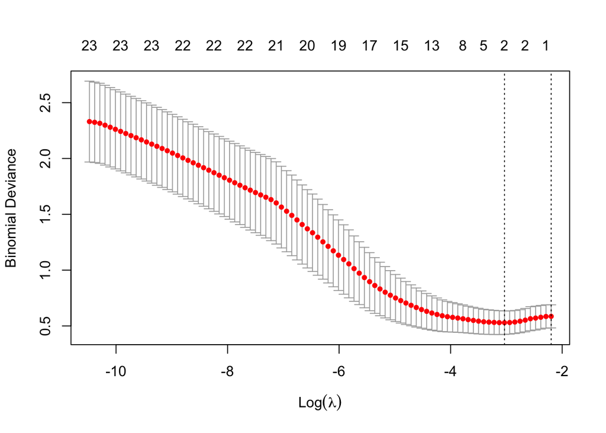

```r
library(glmnet)
set.seed(123)

# Prepare the response variable
y <- unique_subset_data$ctDNA_ever


#was getting an error message when I ran y and X2 because there were 4 missing observations, so will impute these as it is only 4 and missingness is lo (<10%)
library(mice)
# Impute missing values (as general missingness is low as above)
imputed_data <- mice(unique_subset_data, m = 1, method = "pmm", maxit = 5)
unique_subset_data <- complete(imputed_data)

#-1 to not include intercept in this matrix as a predictor variable
X2 <- model.matrix(ctDNA_ever ~ -1 + age_at_diag + final_receptor_group + demo_race_final+
                                   final_tumor_grade + final_overall_stage +
                                      + final_t_stage + final_n_stage +
                                      histology_category + prtx_radiation +
                                      + prtx_chemo + prtx_endo + prtx_bonemod +
                                      node_status + axillary_dissection +
                                      diag_surgery_type_1 + diag_neoadj_chemo_1, data = unique_subset_data)



# Fit lasso model
lasso_model <- glmnet(X2, y, family = "binomial", alpha = 1)  # alpha = 1 for lasso

#Cross-validation. This approach performs k-fold cross validation to find the best lambda. The smaller the lambda, the more variables are included.
cv_lasso_model <- cv.glmnet(X2, y, family = "binomial", alpha = 1)
#plotting the results to look at the performance of different lamda
plot(cv_lasso_model)
```

```r
#getting the best lambda  -- 0.052
best_lambda <- cv_lasso_model$lambda.min
print(paste("Best lambda:", best_lambda))
```

```
[1] "Best lambda: 0.048114238291791"
```

```r
#Finding the final fit model with the optimal lambda
final_lasso_model <- glmnet(X2, y, family = "binomial", alpha = 1, lambda = best_lambda)

#Which coefficents are included in the model.
coef(final_lasso_model)
```

```
29 x 1 sparse Matrix of class "dgCMatrix"
                                              s0
(Intercept)                            -2.762725
age_at_diag                             .
final_receptor_groupTNBC                .
final_receptor_groupHR+ HER2-           .
final_receptor_groupHR+ HER2+           .
final_receptor_groupHR- HER2+           .
demo_race_finalAsian                    .
demo_race_finalWhite                    .
final_tumor_gradeGrade 1                .
final_tumor_gradeGrade 2                .
final_overall_stageStage II             .
final_overall_stageStage III            .
final_t_stageT2                         .
final_t_stageT3                         .
final_t_stageT4                         1.189380
final_n_stageN1                         .
final_n_stageN2                         1.573283
final_n_stageN3                         .
histology_categoryDuctal                .
histology_categoryLobular               .
histology_categoryOther                 .
prtx_radiationRadiation                 .
prtx_chemoChemo                         .
prtx_endoEndocrine Therapy              .
prtx_bonemodBone Modifying Treatment    .
node_statusNode Positive                .
axillary_dissectionAxillary Dissection  .
diag_surgery_type_1Mastectomy           .
diag_neoadj_chemo_1Neoadjuvant Chemo    .
```

Variables that remain significant in the LASSO for ctDNA positivity are t-stage and n-stage. It is slightly challenging to interpret these multi-level variables (such as T-stage and N stage) in the lasso but you can see that higher categories (T4, N2) are associated with positivity in the LASSO. The lambda for this model is quite low at 0.05. It is important to remember that a number of these variables are related to one another (such as T stage and N stage with final overall stage, which is built based on T and N stage), and node status + N stage (node status being built on N stage). I’ll try a few other LASSOs to see whether by eliminating one of each of these colinear variables we get different results.

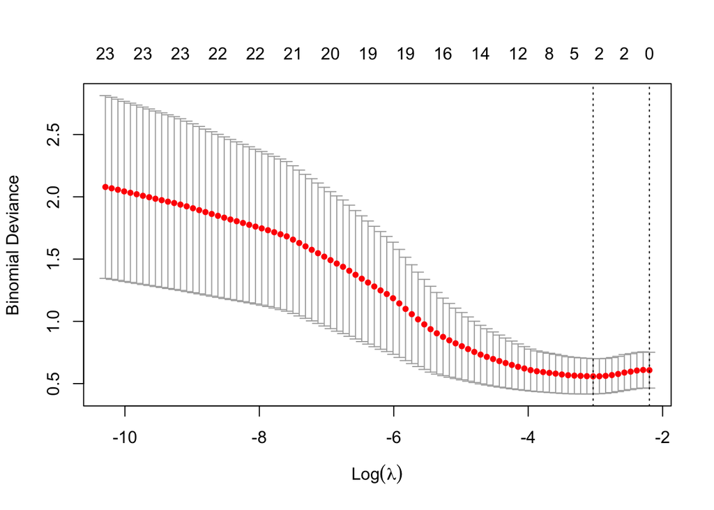

```r
library(glmnet)

set.seed(123) #to ensure consistency of results

# Prepare the response variable
y <- unique_subset_data$ctDNA_ever

#yet again, the same 4 missing observations in X3, so will impute (only 4 observations). We have already imputed these, so I don't need to do it again for unique_subset_Data


### removed Nodal status as a variable
X3 <- model.matrix(ctDNA_ever ~ -1 + age_at_diag + final_receptor_group + demo_race_final+
                                   final_tumor_grade + final_overall_stage +
                                      + final_t_stage + final_n_stage +
                                      histology_category + prtx_radiation +
                                      + prtx_chemo + prtx_endo + prtx_bonemod
                                       + axillary_dissection +
                                      diag_surgery_type_1 + diag_neoadj_chemo_1, data = unique_subset_data)

# Fit lasso model
lasso_model <- glmnet(X3, y, family = "binomial", alpha = 1)  # alpha = 1 for lasso

#Cross-validation. This approach performs k-fold cross validation to find the best lambda. The smaller the lambda, the more variables are included.
cv_lasso_model <- cv.glmnet(X3, y, family = "binomial", alpha = 1)
#plotting the results to look at the performance of different lamda
plot(cv_lasso_model)
```

```r
#getting the best lambda  -- 0.048, lower
best_lambda <- cv_lasso_model$lambda.min
print(paste("Best lambda:", best_lambda))
```

```
[1] "Best lambda: 0.048114238291791"
```

```r
#Finding the final fit model with the optimal lambda
paired_down_lasso <- glmnet(X3, y, family = "binomial", alpha = 1, lambda = best_lambda)

#Which coefficents are included in the model.
coef(paired_down_lasso)
```

```
28 x 1 sparse Matrix of class "dgCMatrix"
                                              s0
(Intercept)                            -2.762725
age_at_diag                             .
final_receptor_groupTNBC                .
final_receptor_groupHR+ HER2-           .
final_receptor_groupHR+ HER2+           .
final_receptor_groupHR- HER2+           .
demo_race_finalAsian                    .
demo_race_finalWhite                    .
final_tumor_gradeGrade 1                .
final_tumor_gradeGrade 2                .
final_overall_stageStage II             .
final_overall_stageStage III            .
final_t_stageT2                         .
final_t_stageT3                         .
final_t_stageT4                         1.189380
final_n_stageN1                         .
final_n_stageN2                         1.573283
final_n_stageN3                         .
histology_categoryDuctal                .
histology_categoryLobular               .
histology_categoryOther                 .
prtx_radiationRadiation                 .
prtx_chemoChemo                         .
prtx_endoEndocrine Therapy              .
prtx_bonemodBone Modifying Treatment    .
axillary_dissectionAxillary Dissection  .
diag_surgery_type_1Mastectomy           .
diag_neoadj_chemo_1Neoadjuvant Chemo    .
```

It is, however, somewhat challenging to model ctDNA positivity using any of these approaches because there were only 9 individuals in this cohort of 109 individuals with positive results. Because of this low N, it is hard to know exactly what to do with these predictors.

The intercept (-2.76) is the log-odds of the outcome (ctDNA positivity or DTC positivity) when all the predictor variables are zero. The coefficients can be interpreted as the amount/times the log odds increases (or decreases) for that cohort, holding all other variables equal.

To test our proof of principle approach that lasso can be applied to this dataset and perhaps generate more robust results, we will also look at DTC predictors, as DTC positivity was more frequent in this cohort and we therefore suspect the modeling approach may work better.

```r
set.seed(123)

#### DTC predictions.

subset_data <- subset_data[!duplicated(subset_data$participant_id), ]
dtc_unique_subset_data <- merge(unique_subset_data, subset_data[, c("participant_id", "dtc_ever")], by = "participant_id", all.x = TRUE)

nrow(dtc_unique_subset_data)  # Should still be 109
```

```
[1] 109
```

```r
table(dtc_unique_subset_data$dtc_ever, useNA = "ifany")  # Check for NA values
```

```
 0  1
70 39
```

```r
#run the lasso for DTC status. This might work better as there are more DTC + results
y1 <- dtc_unique_subset_data$dtc_ever
X2 #use the same X2 as it has the same predictors we are interested in
```

[output not shown]

[output cut: 1243 more lines]

```r
dim(X2)  # Rows should match nrow(dtc_unique_subset_data)
```

```
[1] 109  28
```

```r
length(y1)  # Should also match nrow(dtc_unique_subset_data). We have the same # (109)!
```

```
[1] 109
```

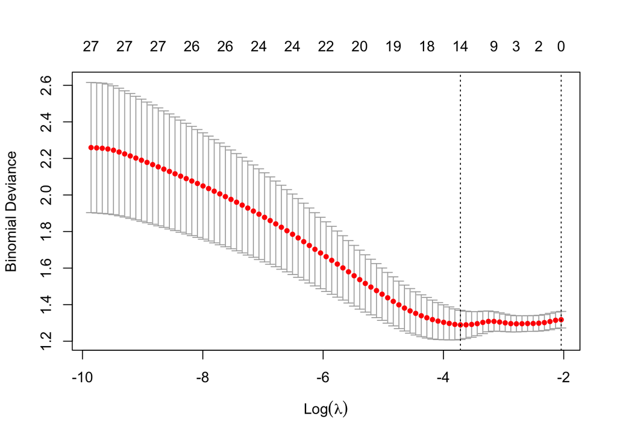

```r
lasso_model <- glmnet(X2, y1, family = "binomial", alpha = 1)  # alpha = 1 for lasso. 0 for ridge.

#Cross-validation. This approach performs k-fold cross validation to find the best lambda. The smaller the lambda, the more variables are included.
cv_lasso_model <- cv.glmnet(X2, y1, family = "binomial", alpha = 1)

#plotting the results to look at the performance of different lamda
plot(cv_lasso_model)
```

```r
#getting the best lambda  -- best lambda is 0.024, even lower!
best_lambda <- cv_lasso_model$lambda.min
print(paste("Best lambda:", best_lambda))
```

```
[1] "Best lambda: 0.0243089462466253"
```

```r
#Finding the final fit model with the optimal lambda
final_lasso_model <- glmnet(X2, y1, family = "binomial", alpha = 1, lambda = best_lambda)

#Which coefficents are included in the model. For the model with DTC positivity, we get more coefficients retained in the model.
coef(final_lasso_model)
```

```
29 x 1 sparse Matrix of class "dgCMatrix"
                                                s0
(Intercept)                            -1.84167985
age_at_diag                             .
final_receptor_groupTNBC                .
final_receptor_groupHR+ HER2-           .
final_receptor_groupHR+ HER2+           0.45710104
final_receptor_groupHR- HER2+          -1.69722848
demo_race_finalAsian                   -0.74138771
demo_race_finalWhite                    .
final_tumor_gradeGrade 1               -0.38615694
final_tumor_gradeGrade 2                .
final_overall_stageStage II             .
final_overall_stageStage III            .
final_t_stageT2                         .
final_t_stageT3                         .
final_t_stageT4                         1.81638875
final_n_stageN1                         .
final_n_stageN2                        -0.02487123
final_n_stageN3                         0.39987630
histology_categoryDuctal                1.10854122
histology_categoryLobular               .
histology_categoryOther                -0.62014177
prtx_radiationRadiation                 0.61433722
prtx_chemoChemo                         .
prtx_endoEndocrine Therapy              .
prtx_bonemodBone Modifying Treatment    0.12821102
node_statusNode Positive               -0.80642910
axillary_dissectionAxillary Dissection  .
diag_surgery_type_1Mastectomy           0.60444202
diag_neoadj_chemo_1Neoadjuvant Chemo    0.23561799
```

```r
#### DTC LASSO without final_n_stage in it

set.seed(123)

#run the lasso for DTC status. This might work better as there are more DTC + results
y1 <- dtc_unique_subset_data$dtc_ever


### removed final_n_stage as a variable
X4 <- model.matrix(ctDNA_ever ~ -1 + age_at_diag + final_receptor_group + demo_race_final+
                                   final_tumor_grade + final_overall_stage +
                                      + final_t_stage  +
                                      histology_category + prtx_radiation +
                                      + prtx_chemo + prtx_endo + prtx_bonemod
                                       + axillary_dissection +  node_status +
                                      diag_surgery_type_1 + diag_neoadj_chemo_1, data = unique_subset_data)



dim(X4)  # Rows should match nrow(dtc_unique_subset_data)
```

```
[1] 109  25
```

```r
length(y1)  # Should also match nrow(dtc_unique_subset_data). We have the same # (109)!
```

```
[1] 109
```

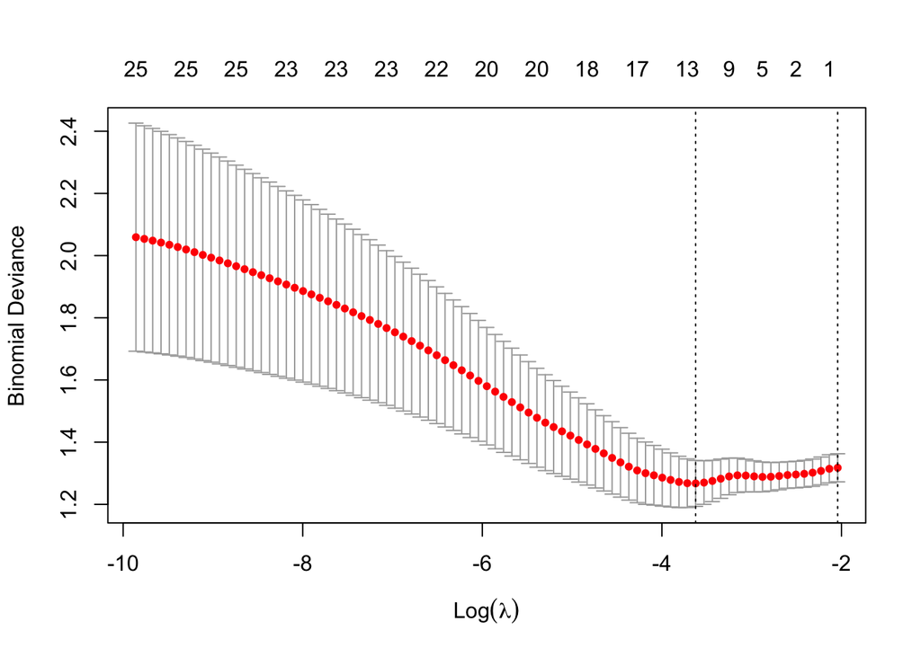

```r
lasso_model <- glmnet(X4, y1, family = "binomial", alpha = 1)  # alpha = 1 for lasso. 0 for ridge.

#Cross-validation. This approach performs k-fold cross validation to find the best lambda. The smaller the lambda, the more variables are included.
cv_lasso_model <- cv.glmnet(X4, y1, family = "binomial", alpha = 1)

#plotting the results to look at the performance of different lamda
plot(cv_lasso_model)
```

```r
#getting the best lambda  -- best lambda is 0.027, same as above
best_lambda <- cv_lasso_model$lambda.min
print(paste("Best lambda:", best_lambda))
```

```
[1] "Best lambda: 0.0266790384961084"
```

```r
#Finding the final fit model with the optimal lambda
final_lasso_model <- glmnet(X3, y1, family = "binomial", alpha = 1, lambda = best_lambda)

#Which coefficents are included in the model. For the model with DTC positivity, we get more coefficients retained in the model. Most notable is the influence of axillary dissection (or none) on the log-odds of dtc positivity.  Other influential factors using LASSO are surgery type (with mastectomy vs lumpectomy increasing the log odds of DTC positivity) and neoadjuvant chemotherapy (with the presence of NACT increasing the log odds of DTC positivity).
coef(final_lasso_model)
```

[output not shown]

## 5 Conclusion

It is worth noting that the ctDNA model in particular is challenging to interpret in the setting of the low number of ctDNA positive individuals (n=9).

Overall, ctDNA status was significantly associated with relapse (p<0.01), with a PPV of 89% and NPV of 94% (and a specificity for relapse of 0.99). DTC positivity was NOT significantly associated with relapse and the sensitivity and specificity of this test for relapse was challenging to interpret in light of the fact that all DTC positive patients in this cohort patients went onto interventional trials aimed at eliminating dormant cancer cells. The negative predictive value of DTC assessment was high (0.86), suggesting that this test may potentially be useful in identifying those individuals who are at lower risk of relapse.

Future directions will be aimed at assessing the test characteristics of DTC assessment in the full cohort of patients on SURMOUNT to date (n=220) and looking at the incremental value of multiple testing, obtaining ctDNA assessment for this full cohort of patients, and performing survival analyses to assess lead time to clinical events (relapse, death) with DTC and ctDNA assessment and looking at the fluctuation of ctDNA positivity among those patients on clinical trials who had frequent testing while on therapy (and following therapy).

We had several limitations: Missing data (though low levels for our variables of interest for this analysis). Our model also includes colinear variables–or variables that represent different ways of thinking about tumor aggressiveness or disease aggressiveness (such as T stage and N stage, which directly feed into Overall Stage) in the LASSO. The LASSO does not account for this, so we will try group lasso as our next step. We also had limited power in creating predictive model for ctDNA in particular given the rarity of positivity in our cohort (though this rate matches the positivity rate in other cohort studies).